# ENV 790.30 - Time Series Analysis for Energy Data | Spring 2024

Assignment 2 - Due date 02/25/24

Julia Kagiliery

## Submission Instructions

You should open the .rmd file corresponding to this assignment on RStudio. The file is available on our class repository on Github.

Once you have the file open on your local machine the first thing you will do is rename the file such that it includes your first and last name (e.g., “LuanaLima_TSA_A02_Sp24.Rmd”). Then change “Student Name” on line 4 with your name.

Then you will start working through the assignment by **creating code and output** that answer each question. Be sure to use this assignment document. Your report should contain the answer to each question and any plots/tables you obtained (when applicable).

When you have completed the assignment, **Knit** the text and code into a single PDF file. Submit this pdf using Sakai.

## R packages

R packages needed for this assignment:“forecast”,“tseries”, and “dplyr”. Install these packages, if you haven’t done yet. Do not forget to load them before running your script, since they are NOT default packages.

```r
#Load/install required package here
library(dplyr)
library(tseries)
library(forecast)
library(lubridate)
```

```r
library(ggplot2)
library(tinytex)
```

## Data set information

Consider the data provided in the spreadsheet “Table_10.1_Renewable_Energy_Production_and_Consumption_by_Source.xlsx” on our **Data** folder. The data comes from the US Energy Information and Administration and corresponds to the December 2023 Monthly Energy Review. The spreadsheet is ready to be used. You will also find a $.csv$ version of the data “Table_10.1_Renewable_Energy_Production_and_Consumption_by_Source-Edit.csv”. You may use the function $read.table()$ to import the $.csv$ data in R. Or refer to the file “M2_ImportingData_CSV_XLSX.Rmd” in our Lessons folder for functions that are better suited for importing the $.xlsx$.

```r
library(readxl)
energy_data <- read_excel(path="~/Julia_Kagiliery_TSA_Sp24/Data/Table_10.1_Renewable_Energy_Production_and_Consumption_by_Source.xlsx",skip = 12, sheet="Monthly Data",col_names=FALSE)
energy_data
```

| ...1 | ...2 | ...3 | ...4 | ...5 | ...6 | ...7 | ...8 | ...9 | ...10 | ...11 | ...12 | ...13 | ...14 |
| --- | --- | --- | --- | --- | --- | --- | --- | --- | --- | --- | --- | --- | --- |
| 1973-01-01 | 129.630 | Not Available | 129.787 | 219.839 | 89.562 | 0.490 | Not Available | Not Available | 129.630 | 0.157 | Not Available | 129.787 | 219.839 |
| 1973-02-01 | 117.194 | Not Available | 117.338 | 197.330 | 79.544 | 0.448 | Not Available | Not Available | 117.194 | 0.144 | Not Available | 117.338 | 197.330 |
| 1973-03-01 | 129.763 | Not Available | 129.938 | 218.686 | 88.284 | 0.464 | Not Available | Not Available | 129.763 | 0.176 | Not Available | 129.938 | 218.686 |
| 1973-04-01 | 125.462 | Not Available | 125.636 | 209.330 | 83.152 | 0.542 | Not Available | Not Available | 125.462 | 0.174 | Not Available | 125.636 | 209.330 |
| 1973-05-01 | 129.624 | Not Available | 129.834 | 215.982 | 85.643 | 0.505 | Not Available | Not Available | 129.624 | 0.210 | Not Available | 129.834 | 215.982 |
| 1973-06-01 | 125.435 | Not Available | 125.611 | 208.249 | 82.060 | 0.579 | Not Available | Not Available | 125.435 | 0.176 | Not Available | 125.611 | 208.249 |
| 1973-07-01 | 129.616 | Not Available | 129.787 | 207.800 | 77.400 | 0.614 | Not Available | Not Available | 129.616 | 0.170 | Not Available | 129.787 | 207.800 |
| 1973-08-01 | 129.734 | Not Available | 129.918 | 203.432 | 72.936 | 0.579 | Not Available | Not Available | 129.734 | 0.184 | Not Available | 129.918 | 203.432 |
| 1973-09-01 | 125.603 | Not Available | 125.782 | 185.300 | 59.029 | 0.490 | Not Available | Not Available | 125.603 | 0.178 | Not Available | 125.782 | 185.300 |
| 1973-10-01 | 129.769 | Not Available | 129.970 | 193.514 | 62.967 | 0.578 | Not Available | Not Available | 129.769 | 0.200 | Not Available | 129.970 | 193.514 |

[output cut: 599 more lines]

## Question 1

You will work only with the following columns: Total Biomass Energy Production, Total Renewable Energy Production, Hydroelectric Power Consumption. Create a data frame structure with these three time series only. Use the command head() to verify your data.

```r
energy_data1 <- energy_data[,4:6]
```

```r
colnames(energy_data1) <- c('Total Biomass Energy Production', 'Total Renewable Energy Production', 'Hydroelectric Power Consumption')
head(energy_data1)
```

| Total Biomass Energy Production | Total Renewable Energy Production | Hydroelectric Power Consumption |
| --- | --- | --- |
| 129.787 | 219.839 | 89.562 |
| 117.338 | 197.330 | 79.544 |
| 129.938 | 218.686 | 88.284 |
| 125.636 | 209.330 | 83.152 |
| 129.834 | 215.982 | 85.643 |
| 125.611 | 208.249 | 82.060 |

## Question 2

Transform your data frame in a time series object and specify the starting point and frequency of the time series using the function ts().

```r
tsenergy <- energy_data1 |>
  ts(start = c(1973,1), frequency = 12)
```

## Question 3

Compute mean and standard deviation for these three series.

```r
library(skimr)
skim(tsenergy)
```

Data summary

| Name | tsenergy |
| --- | --- |
| Number of rows | 609 |
| Number of columns | 3 |
| _______________________ |  |
| Column type frequency: |  |
| numeric | 3 |
| ________________________ |  |
| Group variables | None |

**Variable type: numeric**

| skim_variable | n_missing | complete_rate | mean | sd | p0 | p25 | p50 | p75 | p100 | hist |
| --- | --- | --- | --- | --- | --- | --- | --- | --- | --- | --- |
| Total Biomass Energy Production | 0 | 1 | 279.80 | 92.67 | 114.94 | 222.74 | 254.18 | 373.48 | 469.36 | ▃▇▃▂▃ |
| Total Renewable Energy Production | 0 | 1 | 395.72 | 137.80 | 185.30 | 309.92 | 346.51 | 499.56 | 742.75 | ▃▇▁▂▂ |
| Hydroelectric Power Consumption | 0 | 1 | 79.73 | 14.15 | 49.02 | 69.02 | 78.99 | 89.40 | 119.40 | ▃▇▇▃▁ |

## Question 4

Display and interpret the time series plot for each of these variables. Try to make your plot as informative as possible by writing titles, labels, etc. For each plot add a horizontal line at the mean of each series in a different color.

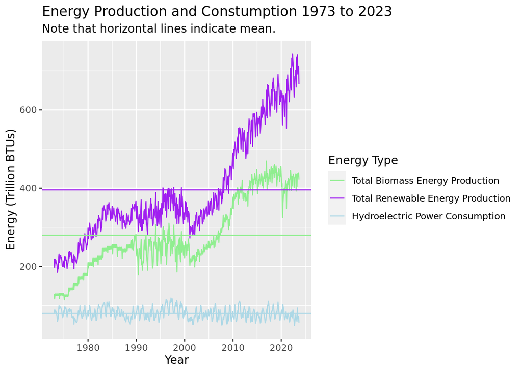

```r
autoplot(tsenergy) +
  xlab("Year") +
  ylab("Energy (Trillion BTUs)") +
  labs(color="Energy Type", title="Energy Production and Constumption 1973 to 2023", subtitle ="Note that horizontal lines indicate mean.") +
  scale_color_manual(values = c("Total Biomass Energy Production" = "lightgreen", "Total Renewable Energy Production"= "purple", "Hydroelectric Power Consumption" = "lightblue")) +
                       geom_hline(yintercept=279.80457, col="lightgreen") +
  geom_hline(yintercept=395.72134, col="purple") +
  geom_hline(yintercept=79.73071, col="lightblue")
```

## Question 5

Compute the correlation between these three series. Are they significantly correlated? Explain your answer.

```r
tsenergy |>
  cor() |>
  print()
```

```
##                                   Total Biomass Energy Production
## Total Biomass Energy Production                        1.00000000
## Total Renewable Energy Production                      0.97074621
## Hydroelectric Power Consumption                       -0.09656318
##                                   Total Renewable Energy Production
## Total Biomass Energy Production                         0.970746212
## Total Renewable Energy Production                       1.000000000
## Hydroelectric Power Consumption                        -0.001768629
##                                   Hydroelectric Power Consumption
## Total Biomass Energy Production                      -0.096563177
## Total Renewable Energy Production                    -0.001768629
## Hydroelectric Power Consumption                       1.000000000
```

It appears as though total biomass energy production and total renewable energy production are strongly positively corelated as they have a correlation coefficient of 0.97075. However, these two are not correlated to hydroelectric power consumption as those coefficents are (in magnitude) lower than 0.7 (about where I would draw the line at taking strong conclusions about correlation).

## Question 6

Compute the autocorrelation function from lag 1 up to lag 40 for these three variables. What can you say about these plots? Do the three of them have the same behavior?

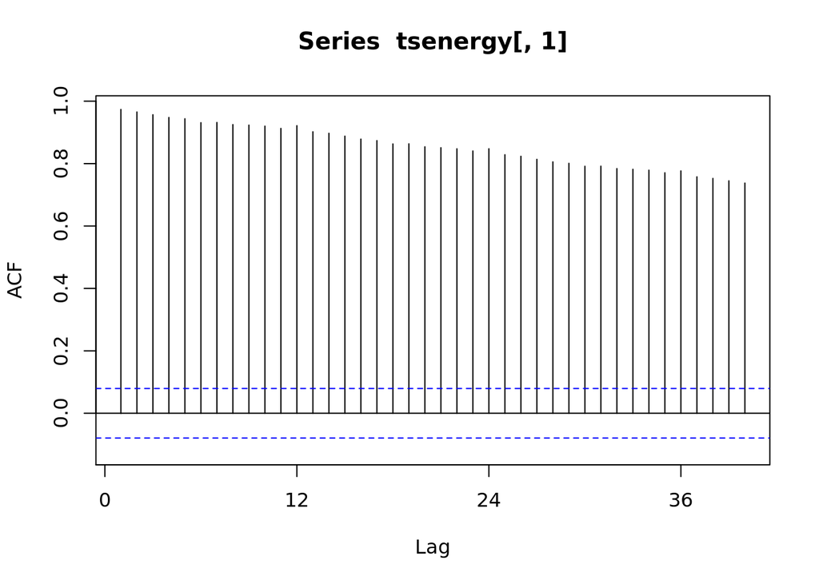

```r
tsenergy[,1] |>
  Acf(lag.max = 40)
```

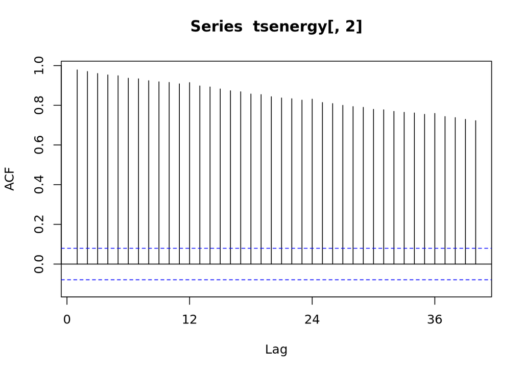

```r
tsenergy[,2] |>
  Acf(lag.max = 40)
```

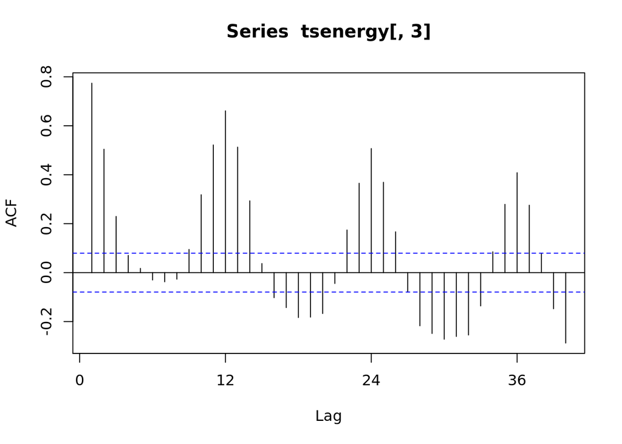

```r
tsenergy[,3] |>
  Acf(lag.max = 40)
```

## Question 7

Compute the partial autocorrelation function from lag 1 to lag 40 for these three variables. How these plots differ from the ones in Q6?

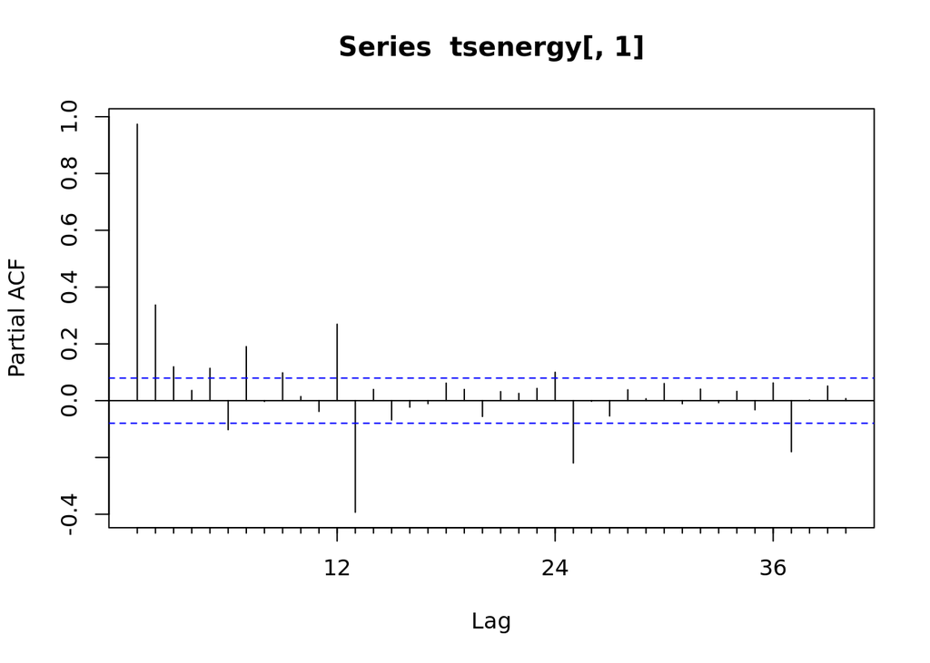

```r
tsenergy[,1] |>
  Pacf(lag.max = 40)
```

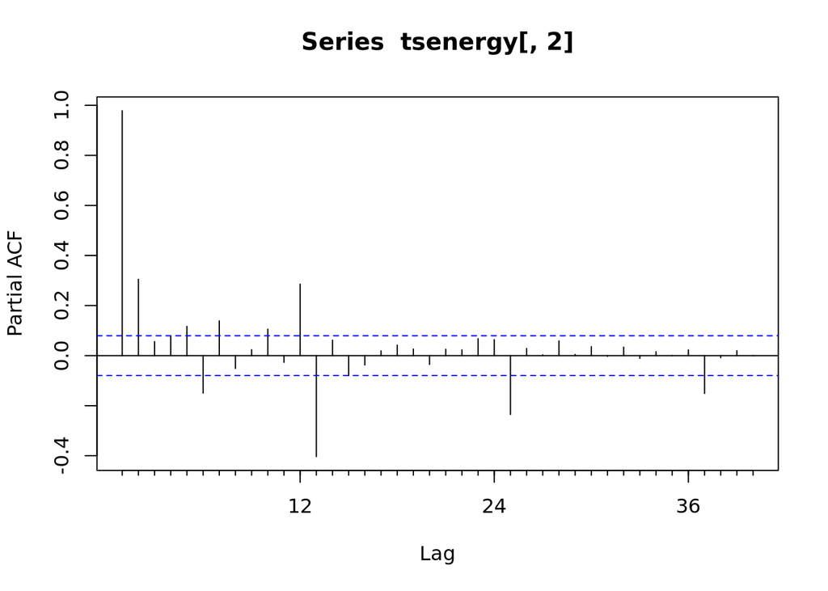

```r
tsenergy[,2] |>
  Pacf(lag.max = 40)
```

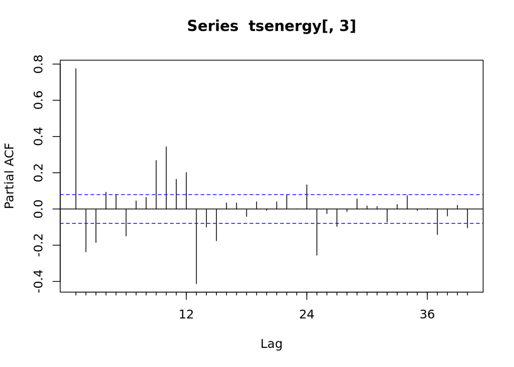

```r
tsenergy[,3] |>
  Pacf(lag.max = 40)
```